# Read in the data

```r
library(data.table)
train_path <- "S:/ACTUARY3/Advanced Analytics/Private/Staff/Chong, Fan Fei/arch_kaggle_data/out/train_weighted.csv"
train = read.csv(train_path, stringsAsFactors= T, na.strings=".")
valid_path <- "S:/ACTUARY3/Advanced Analytics/Private/Staff/Chong, Fan Fei/arch_kaggle_data/out/valid_weighted.csv"
valid = read.csv(valid_path, stringsAsFactors= T, na.strings=".")
test_path <- "S:/ACTUARY3/Advanced Analytics/Private/Staff/Chong, Fan Fei/arch_kaggle_data/in/application_test.csv"
test = read.csv(test_path, stringsAsFactors= T)

library(dplyr)
library(rms)
library(Hmisc)
```

# Automatically generate a saturated model (symbolically)

```r
M = train

col_set = M %>% names()
col_set = col_set[!col_set %in% "TARGET"]

string_formula = "TARGET~"
for(i in col_set){
  if(class(M[[i]]) == "numeric"){
    tmp_component = paste0("+rcs(",i,",3)")
  }
  if(class(M[[i]]) != "numeric"){
    tmp_component = paste0("+",i)
  }
  string_formula = paste0(string_formula, tmp_component)
}
requested_formula = as.formula(string_formula)
requested_formula
```

```
TARGET ~ +NAME_CONTRACT_TYPE + CODE_GENDER + FLAG_OWN_CAR + FLAG_OWN_REALTY +
    CNT_CHILDREN + rcs(AMT_INCOME_TOTAL, 3) + rcs(AMT_CREDIT,
    3) + rcs(AMT_ANNUITY, 3) + rcs(AMT_GOODS_PRICE, 3) + NAME_TYPE_SUITE +
    NAME_INCOME_TYPE + NAME_EDUCATION_TYPE + NAME_FAMILY_STATUS +
    NAME_HOUSING_TYPE + rcs(REGION_POPULATION_RELATIVE, 3) +
    DAYS_BIRTH + DAYS_EMPLOYED + rcs(DAYS_REGISTRATION, 3) +
    DAYS_ID_PUBLISH + OWN_CAR_AGE + FLAG_MOBIL + FLAG_EMP_PHONE +
    FLAG_WORK_PHONE + FLAG_CONT_MOBILE + FLAG_PHONE + FLAG_EMAIL +
    OCCUPATION_TYPE + CNT_FAM_MEMBERS + REGION_RATING_CLIENT +
    REGION_RATING_CLIENT_W_CITY + WEEKDAY_APPR_PROCESS_START +
    HOUR_APPR_PROCESS_START + REG_REGION_NOT_LIVE_REGION + REG_REGION_NOT_WORK_REGION +
    LIVE_REGION_NOT_WORK_REGION + REG_CITY_NOT_LIVE_CITY + REG_CITY_NOT_WORK_CITY +
    LIVE_CITY_NOT_WORK_CITY + ORGANIZATION_TYPE + rcs(EXT_SOURCE_1,
    3) + rcs(EXT_SOURCE_2, 3) + rcs(EXT_SOURCE_3, 3) + rcs(APARTMENTS_AVG,
    3) + rcs(BASEMENTAREA_AVG, 3) + rcs(YEARS_BEGINEXPLUATATION_AVG,
    3) + rcs(YEARS_BUILD_AVG, 3) + rcs(COMMONAREA_AVG, 3) + rcs(ELEVATORS_AVG,
    3) + rcs(ENTRANCES_AVG, 3) + rcs(FLOORSMAX_AVG, 3) + rcs(FLOORSMIN_AVG,
    3) + rcs(LANDAREA_AVG, 3) + rcs(LIVINGAPARTMENTS_AVG, 3) +
    rcs(LIVINGAREA_AVG, 3) + rcs(NONLIVINGAPARTMENTS_AVG, 3) +
    rcs(NONLIVINGAREA_AVG, 3) + rcs(APARTMENTS_MODE, 3) + rcs(BASEMENTAREA_MODE,
    3) + rcs(YEARS_BEGINEXPLUATATION_MODE, 3) + rcs(YEARS_BUILD_MODE,
    3) + rcs(COMMONAREA_MODE, 3) + rcs(ELEVATORS_MODE, 3) + rcs(ENTRANCES_MODE,
    3) + rcs(FLOORSMAX_MODE, 3) + rcs(FLOORSMIN_MODE, 3) + rcs(LANDAREA_MODE,
    3) + rcs(LIVINGAPARTMENTS_MODE, 3) + rcs(LIVINGAREA_MODE,
    3) + rcs(NONLIVINGAPARTMENTS_MODE, 3) + rcs(NONLIVINGAREA_MODE,
    3) + rcs(APARTMENTS_MEDI, 3) + rcs(BASEMENTAREA_MEDI, 3) +
    rcs(YEARS_BEGINEXPLUATATION_MEDI, 3) + rcs(YEARS_BUILD_MEDI,
    3) + rcs(COMMONAREA_MEDI, 3) + rcs(ELEVATORS_MEDI, 3) + rcs(ENTRANCES_MEDI,
    3) + rcs(FLOORSMAX_MEDI, 3) + rcs(FLOORSMIN_MEDI, 3) + rcs(LANDAREA_MEDI,
    3) + rcs(LIVINGAPARTMENTS_MEDI, 3) + rcs(LIVINGAREA_MEDI,
    3) + rcs(NONLIVINGAPARTMENTS_MEDI, 3) + rcs(NONLIVINGAREA_MEDI,
    3) + FONDKAPREMONT_MODE + HOUSETYPE_MODE + rcs(TOTALAREA_MODE,
    3) + WALLSMATERIAL_MODE + EMERGENCYSTATE_MODE + OBS_30_CNT_SOCIAL_CIRCLE +
    DEF_30_CNT_SOCIAL_CIRCLE + OBS_60_CNT_SOCIAL_CIRCLE + DEF_60_CNT_SOCIAL_CIRCLE +
    DAYS_LAST_PHONE_CHANGE + FLAG_DOCUMENT_2 + FLAG_DOCUMENT_3 +
    FLAG_DOCUMENT_4 + FLAG_DOCUMENT_5 + FLAG_DOCUMENT_6 + FLAG_DOCUMENT_7 +
    FLAG_DOCUMENT_8 + FLAG_DOCUMENT_9 + FLAG_DOCUMENT_10 + FLAG_DOCUMENT_11 +
    FLAG_DOCUMENT_12 + FLAG_DOCUMENT_13 + FLAG_DOCUMENT_14 +
    FLAG_DOCUMENT_15 + FLAG_DOCUMENT_16 + FLAG_DOCUMENT_17 +
    FLAG_DOCUMENT_18 + FLAG_DOCUMENT_19 + FLAG_DOCUMENT_20 +
    FLAG_DOCUMENT_21 + AMT_REQ_CREDIT_BUREAU_HOUR + AMT_REQ_CREDIT_BUREAU_DAY +
    AMT_REQ_CREDIT_BUREAU_WEEK + AMT_REQ_CREDIT_BUREAU_MON +
    AMT_REQ_CREDIT_BUREAU_QRT + AMT_REQ_CREDIT_BUREAU_YEAR +
    test_ind + rcs(weight, 3) + split
```

# Prelim Model with no missing value imputation

```r
# would work
string_formula <- TARGET ~ NAME_CONTRACT_TYPE + CODE_GENDER + FLAG_OWN_CAR + rcs(EXT_SOURCE_1, 4) + rcs(EXT_SOURCE_2, 4) + rcs(EXT_SOURCE_3, 4)
requested_formula = as.formula(string_formula)
a_model = lrm(data=M, formula = requested_formula, weight=weight, x=TRUE, y=TRUE)
```

```r
library(pander)
```

```r
a_model
```

Frequencies of Missing Values Due to Each Variable TARGET NAME_CONTRACT_TYPE CODE_GENDER 0 0 0 FLAG_OWN_CAR EXT_SOURCE_1 EXT_SOURCE_2 0 13872 53 EXT_SOURCE_3 (weights) 4844 0

Logistic Regression Model

lrm(formula = requested_formula, data = M, x = TRUE, y = TRUE, weights = weight)

Sum of Weights by Response Category

```
     0         1
```

33884.964 2443.623

```
                        Model Likelihood     Discrimination    Rank Discrim.
                           Ratio Test           Indexes           Indexes
```

Obs 8719 LR chi2 2307.94 R2 0.158 C 0.757  
0 8115 d.f. 12 g 1.146 Dxy 0.514  
1 604 Pr(> chi2) <0.0001 gr 3.147 gamma 0.520  
Sum of weights36328.59 gp 0.066 tau-a 0.064  
max |deriv| 6e-13 Brier 0.057

```
                                Coef    S.E.   Wald Z Pr(>|Z|)
```

Intercept 0.7552 0.1383 5.46 <0.0001 NAME_CONTRACT_TYPE=Revolving loans -0.7474 0.1793 -4.17 <0.0001 CODE_GENDER=M 0.1445 0.0499 2.90 0.0038  
FLAG_OWN_CAR=Y -0.1820 0.0478 -3.81 0.0001  
EXT_SOURCE_1 -2.6188 0.3757 -6.97 <0.0001 EXT_SOURCE_1' 1.5428 1.2053 1.28 0.2005  
EXT_SOURCE_1'' 2.6212 4.3582 0.60 0.5476  
EXT_SOURCE_2 -1.6143 0.3224 -5.01 <0.0001 EXT_SOURCE_2' -1.1780 0.6220 -1.89 0.0583  
EXT_SOURCE_2'' 0.0739 6.1218 0.01 0.9904  
EXT_SOURCE_3 -2.6895 0.3016 -8.92 <0.0001 EXT_SOURCE_3' -4.7078 0.8674 -5.43 <0.0001 EXT_SOURCE_3'' 35.6799 5.0235 7.10 <0.0001

A really basic model because of the extensive missing values, If we add an additional variable AMT_CREDIT, there would be so much case deletion that the model won't even be fitted at all. Error Message:

(singular information matrix in lrm.fit (rank= 9 ). Offending variable(s): EXT_SOURCE_3' EXT_SOURCE_2' EXT_SOURCE_1' )

```r
# Model that did not work
# would not work
#string_formula <- TARGET ~ NAME_CONTRACT_TYPE + CODE_GENDER + FLAG_OWN_CAR + rcs(EXT_SOURCE_1, 3) + rcs(EXT_SOURCE_2, 3) + rcs(EXT_SOURCE_3, 3)+
#  rcs(AMT_CREDIT, 3)
# requested_formula = as.formula(string_formula)
# a_model = lrm(data=M, formula = requested_formula, weight=weight)
```

## Use the fitted model to score a dataset

```r
valid_scored <- cbind(valid, predict(a_model, valid, se.fit=TRUE))
test_scored <- cbind(test, predict(a_model, test, se.fit=TRUE))
head(test_scored$linear.predictors)
```

```
[1] -2.842605 -2.229236        NA -3.762390        NA        NA
```

## Diagnostic plots

### Variable Importance

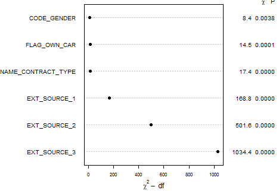

```r
plot(anova(a_model))
```

### Partial Effect Plot

```r
dd <- datadist(train); options(datadist='dd')
```

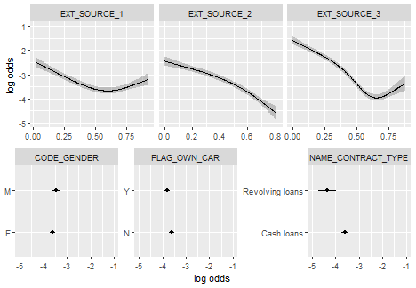

```r
ggplot(Predict(a_model),sepdiscrete='vertical',vnames='names')#,
       #rdata=train,histSpike.opts=list(frac=function(f) .1*
        #                                 f/max(f)))
```

### Validation Statistics

```r
validate(a_model, B=100)
```

```
          index.orig training    test optimism index.corrected   n
Dxy           0.4750   0.5025  0.4904   0.0121          0.4629 100
R2            0.1581   0.1412  0.1338   0.0074          0.1508 100
Intercept     0.0000   0.0000 -0.0592   0.0592         -0.0592 100
Slope         1.0000   1.0000  0.9731   0.0269          0.9731 100
Emax          0.0000   0.0000  0.0175   0.0175          0.0175 100
D             0.2646   0.0574  0.0543   0.0031          0.2615 100
U            -0.0002  -0.0002  0.0001  -0.0003          0.0001 100
Q             0.2648   0.0576  0.0542   0.0034          0.2614 100
B             0.0601   0.0596  0.0600  -0.0004          0.0605 100
g             1.1463   1.0178  0.9890   0.0288          1.1175 100
gp            0.0664   0.0642  0.0627   0.0015          0.0649 100
```

```r
# create artificial scores as random numbers
# x <- rnorm( 1000 );
# y <- rnorm( 1000, -1 );
# create artificial weights
# x.weights <- runif( 1000 );
# y.weights <- runif( 1000 );
# compute ROC curve and area under curve
# roc <- roc.curve( x, y, x.weights, y.weights, curve = TRUE );
```

### Calibration Curve

```
n=8719   Mean absolute error=0.007   Mean squared error=7e-05
0.9 Quantile of absolute error=0.009
```

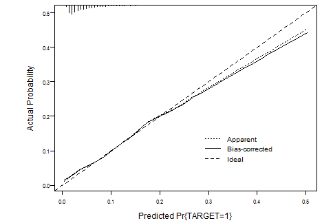

```r
plot(calibrate(a_model, B=100))
```

We see that only 8719 out of 24575 observations are used. Missing out a lot.

# Handling Missing Values

## Check out missing patterns

[figure not shown]

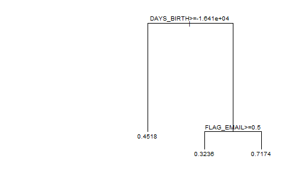

```r
na.patterns <- naclus(train)
require(rpart)
who.na <- rpart(is.na(EXT_SOURCE_1) ~ . - EXT_SOURCE_1, data=train,minbucket=15)
naplot(na.patterns, 'na per var')
plot(who.na, margin = .1); text(who.na)
#plot(na.pattterns)
```